# R for cytometry course

Part 2: Plotting data with ggplot2

Hefin Rhys

2021-07-01

# 1 What is ggplot2?

R is great for creating plots and comes with its own base functions for doing so. But creating and customising complex plots with base R can be a little cumbersome. Instead, you can achieve beautiful, publication-ready plots much faster and more easily using the *ggplot2* plotting package.

The “gg” in ggplot2 stands for “grammar of graphics”, which is a school of thought that says any plot can be constructed by adding sequential layers of elements, such as axes, dots, and lines. The ggplot2 package makes constructing plots in this way very easy.

# 2 Installing and loading the packages

We’ll start by installing the ggplot2 package from CRAN, and also the *palmerpenguins* package, that comes with some cute example data we will plot.

```r
#install.packages("ggplot2")
#install.packages("palmerpenguins")
library(ggplot2)
library(palmerpenguins)
```

# 3 Loading package datasets

R comes with a large variety of example datasets you can freely load and experiment with. Executing `data()` will open a new tab in RStudio listing all the datasets available in base R and the loaded packages. You can search for datasets in a particular package by using the `package` argument. To load a dataset, simply pass it as the argument to the `data()` function, and it will be loaded into your environment. Below, we load the *penguins* dataset.

> Note that the penguins object is a *tibble* not a data.frame. A tibble can largely be treated the same as a data.frame, but it is more pleasing and easier to read when printed.

```r
data()
data(package = "palmerpenguins")
data(penguins)
penguins
```

```
## # A tibble: 344 x 8
##    species island    bill_length_mm bill_depth_mm flipper_length_mm body_mass_g
##    <fct>   <fct>              <dbl>         <dbl>             <int>       <int>
##  1 Adelie  Torgersen           39.1          18.7               181        3750
##  2 Adelie  Torgersen           39.5          17.4               186        3800
##  3 Adelie  Torgersen           40.3          18                 195        3250
##  4 Adelie  Torgersen           NA            NA                  NA          NA
##  5 Adelie  Torgersen           36.7          19.3               193        3450
##  6 Adelie  Torgersen           39.3          20.6               190        3650
##  7 Adelie  Torgersen           38.9          17.8               181        3625
##  8 Adelie  Torgersen           39.2          19.6               195        4675
##  9 Adelie  Torgersen           34.1          18.1               193        3475
## 10 Adelie  Torgersen           42            20.2               190        4250
## # ... with 334 more rows, and 2 more variables: sex <fct>, year <int>
```

```r
str(penguins)
```

```
## tibble[,8] [344 x 8] (S3: tbl_df/tbl/data.frame)
##  $ species          : Factor w/ 3 levels "Adelie","Chinstrap",..: 1 1 1 1 1 1 1 1 1 1 ...
##  $ island           : Factor w/ 3 levels "Biscoe","Dream",..: 3 3 3 3 3 3 3 3 3 3 ...
##  $ bill_length_mm   : num [1:344] 39.1 39.5 40.3 NA 36.7 39.3 38.9 39.2 34.1 42 ...
##  $ bill_depth_mm    : num [1:344] 18.7 17.4 18 NA 19.3 20.6 17.8 19.6 18.1 20.2 ...
##  $ flipper_length_mm: int [1:344] 181 186 195 NA 193 190 181 195 193 190 ...
##  $ body_mass_g      : int [1:344] 3750 3800 3250 NA 3450 3650 3625 4675 3475 4250 ...
##  $ sex              : Factor w/ 2 levels "female","male": 2 1 1 NA 1 2 1 2 NA NA ...
##  $ year             : int [1:344] 2007 2007 2007 2007 2007 2007 2007 2007 2007 2007 ...
```

# 4 Plotting with base R

We’re not going to spend time learning to plot in base R, but just to give you a flavour, here are some examples. Just calling `plot()` on a data.frame will plot each variable against every other variable. To create a scatter plot, we must supply vectors representing the x and y axes, and (optionally) a vector for the colours.

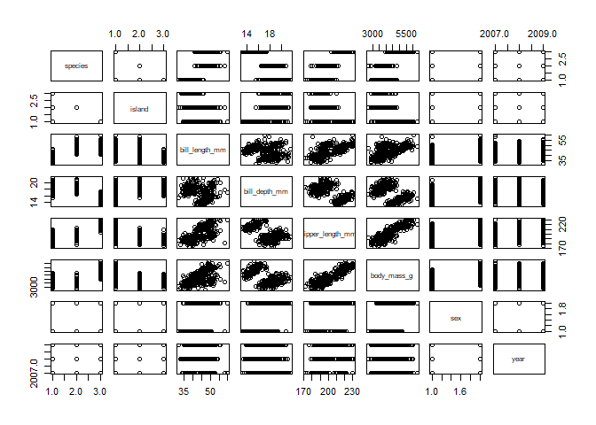

```r
plot(penguins)
```

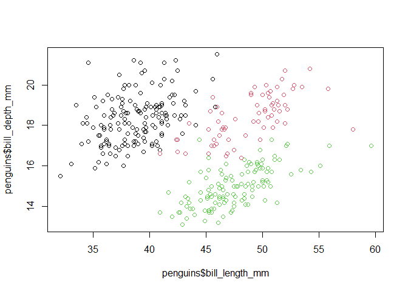

```r
plot(penguins$bill_length_mm, penguins$bill_depth_mm, col = penguins$species)
```

# 5 Plotting with ggplot2

When creating a plot with ggplot2, we always start with the `ggplot()` function. The first argument is the data, the second argument is another function, `aes()`. This function allows us to specify the plot’s *aesthetic mappings*.

An aesthetic mapping is the link between a graphical aspect of the plot (such as the x or y coordinate, or the colour of the dots) and a variable in the data. The example below maps the bill_length_mm variable to the x aesthetic, maps the bill_depth_mm variable to the y aesthetic, and maps the species variable to the col (colour) aesthetic.

This function creates the plotting space and axes, but in order to see our data visualised we must add a geom (short for geometric object) layer. To add dots or points, we add a `geom_point()` layer to the plot, using the `+` symbol.

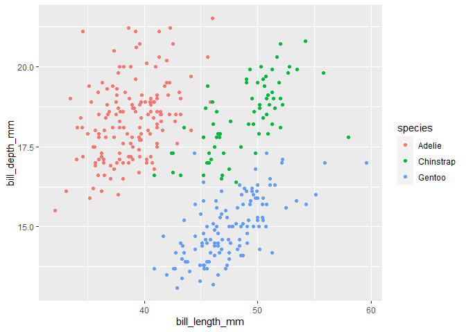

```r
ggplot(penguins, aes(x = bill_length_mm, y = bill_depth_mm, col = species)) +
  geom_point()
```

## 5.1 Exploring additional aesthetic mappings

We’ve already seen we can map our variables to the x, y, and col aesthetics, but we can map variables to other aspects of our plots. You can find out what aesthetic mappings a geom can/needs to use by using the help system (e.g. `?geom_point()`).

Let’s draw the same plot as above, but this time map the size of each dot to the body_mass_g variable.

> Note that ggplot2 takes care of the legends for you. Base R doesn’t do this.

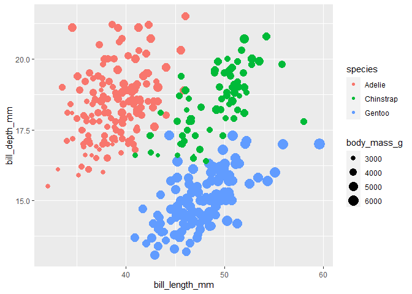

```r
ggplot(penguins, aes(x = bill_length_mm,
                     y = bill_depth_mm,
                     col = species,
                     size = body_mass_g)) +
  geom_point()
```

We could also indicate the sex of the penguin using different shapes. We can change the size of the points by using the `size` argument.

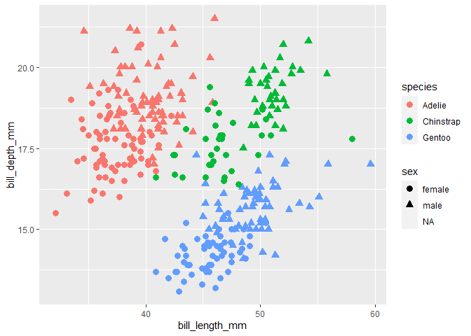

```r
ggplot(penguins, aes(x = bill_length_mm,
                     y = bill_depth_mm,
                     col = species,
                     shape = sex)) +
  geom_point(size = 3)
```

There are others, but these are the main ones you’ll need for the majority of plots.

## 5.2 Exploring additional geoms for scatter plots

ggplot2 has some other geoms that are useful for scatter plots. The `geom_density_2d()` geom is useful for highlighting regions of high density (especially when there are many data). The `stat_ellipse()` stat (a geom that shows some kind of statistical summary of the data) shows a confidence ellipse (95% by default) around groups of observations.

> Note that you can store a ggplot as an object, and then add geoms to it later!

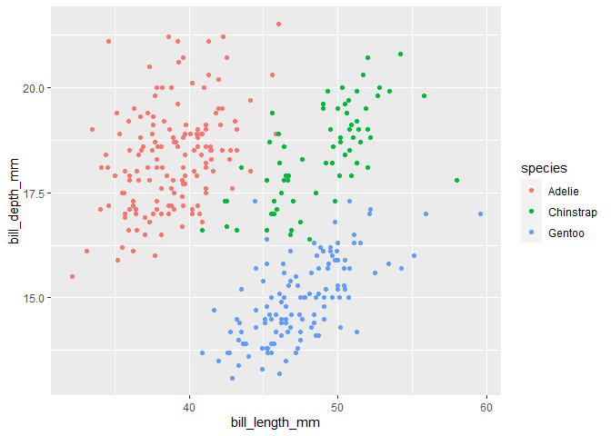

```r
p1 <- ggplot(penguins, aes(x = bill_length_mm, y = bill_depth_mm, col = species))

p1 + geom_point()
```

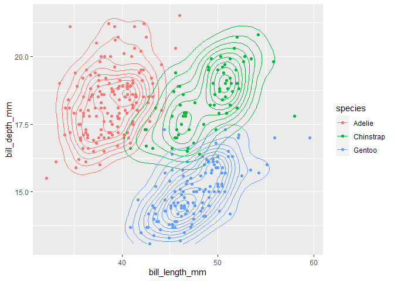

```r
p1 + geom_point() + geom_density_2d()
```

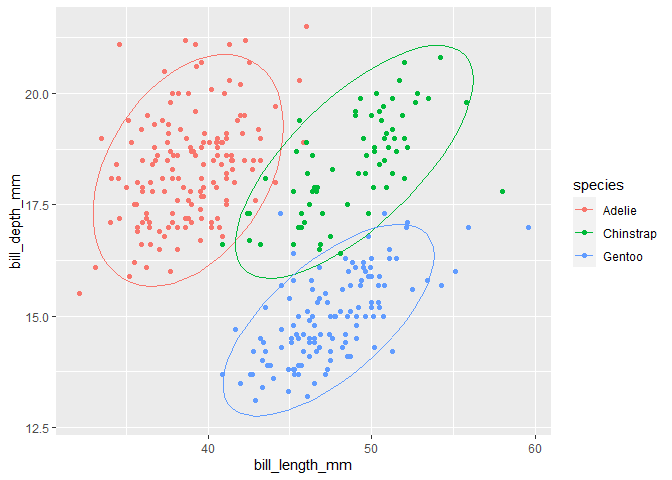

```r
p1 + geom_point() + stat_ellipse()
```

## 5.3 Line plots

```r
data(Orange)
Orange
```

```
##    Tree  age circumference
## 1     1  118            30
## 2     1  484            58
## 3     1  664            87
## 4     1 1004           115
## 5     1 1231           120
## 6     1 1372           142
## 7     1 1582           145
## 8     2  118            33
## 9     2  484            69
## 10    2  664           111
## 11    2 1004           156
## 12    2 1231           172
## 13    2 1372           203
## 14    2 1582           203
```

[output cut: 21 more lines]

Once again, we start with our `ggplot()` call, supplying Orange as the data, and using the `aes()` function to map age to the x axis, circumference to the y axis, and I use the `group` aesthetic to tell ggplot2 I want a separate line for each Tree. If I want a straight line to connect each observation, I can use the `geom_line()` geom, but if I want a smooth trend line across all the values, I can use the `geom_smooth()` geom.

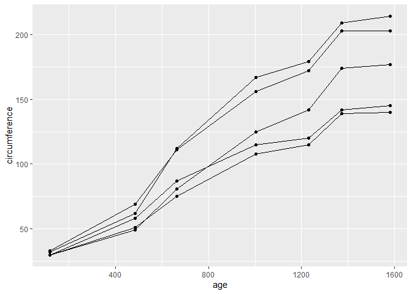

```r
p2 <- ggplot(Orange, aes(age, circumference, group = Tree))
p2 + geom_line() + geom_point()
```

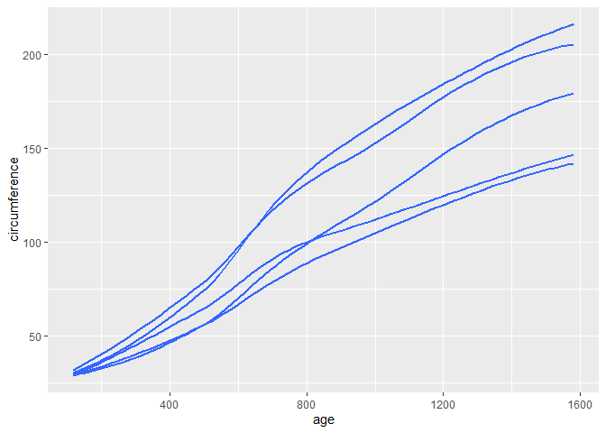

```r
p2 + geom_smooth(se = FALSE)
```

If, instead, we want least squares linear regression lines, we can set the argument `method = lm` (for linear model) and we will get a separate line per group or colour.

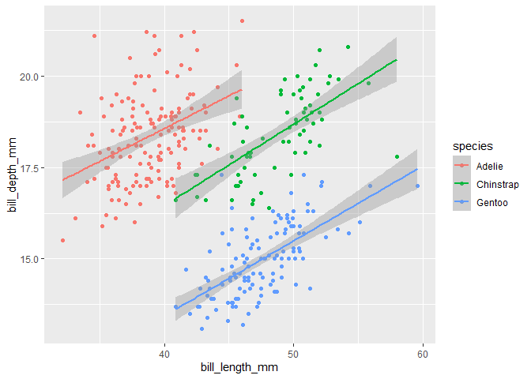

```r
ggplot(penguins, aes(bill_length_mm, bill_depth_mm, col = species)) +
  geom_point() +
  geom_smooth(method = "lm")
```

## 5.4 Bar, boxplot, and violin plots

When plotting a categorical variable against a continuous one, we often make use of bar plots, boxplots, and violin plots.

Let’s start by creating a bar chart to show the frequency of each penguin species. By default `geom_bar()` will assume it is being used to display frequencies, so we only need to specify the x aesthetic mapping.

> Note we can set the fill and colour of geoms manually. The fill is the internal colour, and the col is the colour of the border. The size argument for bars specifies the width of the border.

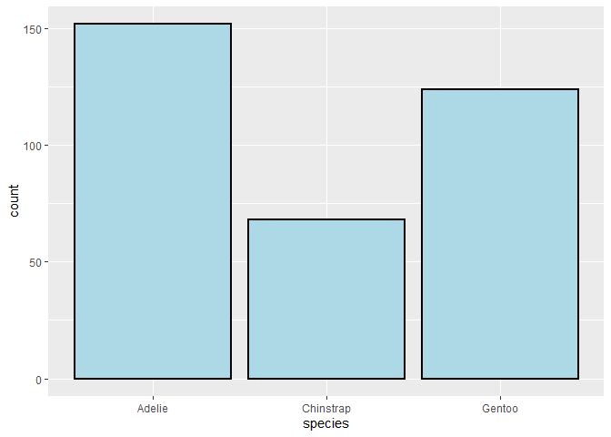

```r
ggplot(penguins, aes(species)) +
    geom_bar(fill = "lightblue", col = "black", size = 1)
```

Let’s store a ggplot as an object so we can experiment with a few things.

```r
p3 <- ggplot(penguins, aes(species, bill_length_mm))
```

Often, we want our bars to indicate a summary statistic of a group, like a mean or median. To do this, we have to tell ggplot we’re plotting a summary statistic using the argument `stat = summary`, and then use the `fun` argument to specify what summary statistic we wish to plot.

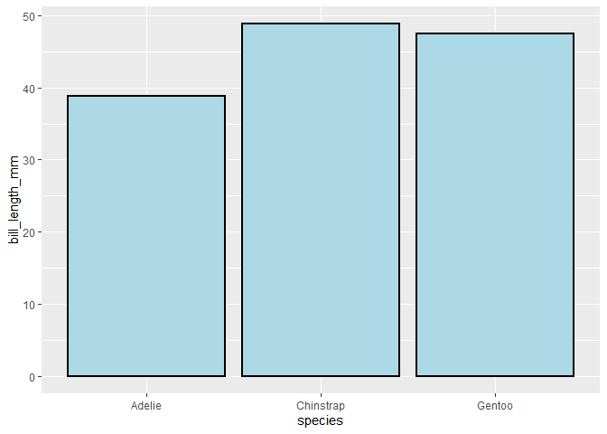

```r
p3 + geom_bar(stat = "summary",
              fun = "mean",
              fill = "lightblue",
              col = "black",
              size = 1)
```

It’s bad practice to show only summary statistics, and showing the raw points along with the mean bars is better.

> Note that to avoid the points sitting on top of each other, we can add a small amount of “jitter” to help us see their distribution.

> Also note that the order of the geoms is important! Try placing the geom_point layer before the geom_bar layer and see what happens!

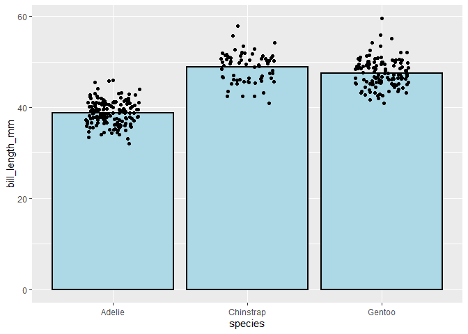

```r
p3 + geom_bar(stat = "summary",
              fun = "mean",
              fill = "lightblue",
              col = "black",
              size = 1) +
    geom_point(position = position_jitter(0.2))
```

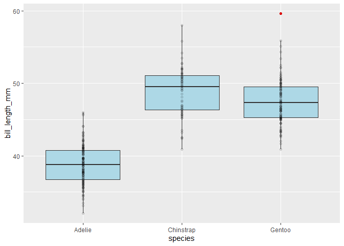

```r
p3 + geom_boxplot(fill = "lightblue", outlier.color = "red") +
    geom_point(alpha = 0.1)
```

Similar to a boxplot, you can use a geom_violin() geom to show the distribution of points for each group. The `draw_quantiles` argument takes a vector of quantiles to draw. In the example below, I used the 1st and 3rd quartiles. I also use a `geom_point()` layer to show the median for each group, just like we did with `geom_bar()`.

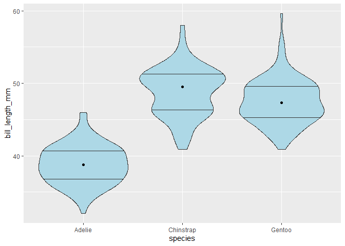

```r
p3 + geom_violin(fill = "lightblue", draw_quantiles = c(0.25, 0.75)) +
    geom_point(stat = "summary", fun = "median")
```

## 5.5 Factorial bar graphs

Sometimes we might want to plot an outcome variable, across the values of two (or more) categorical variables. Let’s say we wish to know how the bill_length_mm variable varies with different combinations of the sex and species variables. For this, we can create a factorial bar graph.

In the example below, we map the sex variable to the x aesthetic, bill_length_mm to the y aesthetic, and species to the fill aesthetic. We add a geom_bar layer that will summarise the median of each group and, importantly, set the argument `position = "dodge"`. This means that bars for the same value of x aesthetic (sex), but a different fill aesthetic (species), will be “dodged” so that they are adjacent to each other, instead of on top of each other. Other position arguments include `"stack"` and `"fill"` (try these out for yourself).

> Note: In order for the `geom_point()` layer to be correctly dodged with the bars, it must use the argument `position = position_dodge(0.9)`.

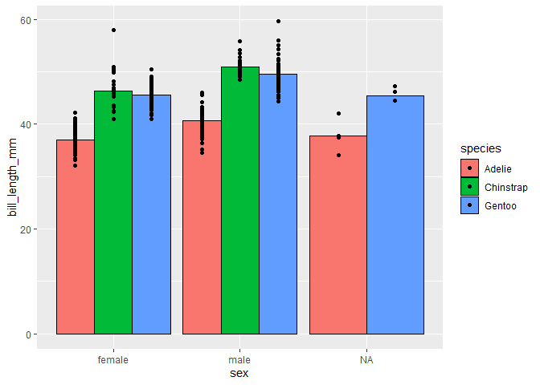

```r
ggplot(penguins, aes(sex, bill_length_mm, fill = species)) +
    geom_bar(stat = "summary", fun = "median", col = "black", position = "dodge") +
    geom_point(position = position_dodge(0.9))
```

## 5.6 Facetting

When we have multiple variables we wish to represent in a plot, we can create clearer, more effective visualisations by splitting the data across subplots, or *facets*. To illustrate this, let’s start by creating a ggplot of bill_length_mm vs. bill_depth_mm, and colouring by the species variable.

```r
p4 <- ggplot(penguins, aes(x = bill_length_mm, y = bill_depth_mm, col = species)) +
    geom_point()
```

If we call our p4 object, we’ll get a scatter plot with all of the data in a single plot, coloured by species. But what if, to make the plot more understandable, we want to separately plot the data for each species? Rather than filtering our data and making three separate plots, we can do this by simply adding a `facet_wrap()` layer, and using a tilde (~) symbol to indicate the variable we wish to facet by.

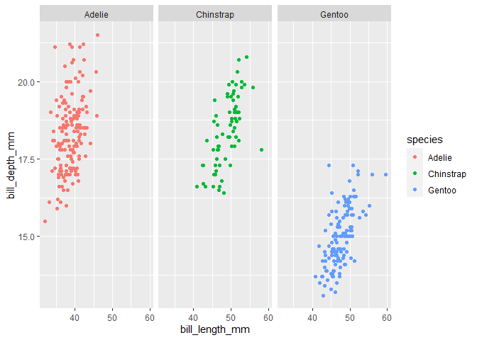

```r
p4 + facet_wrap(~ species)
```

By default, the plot is drawn with the facets all in a single row, but we can change this with the `nrow` argument.

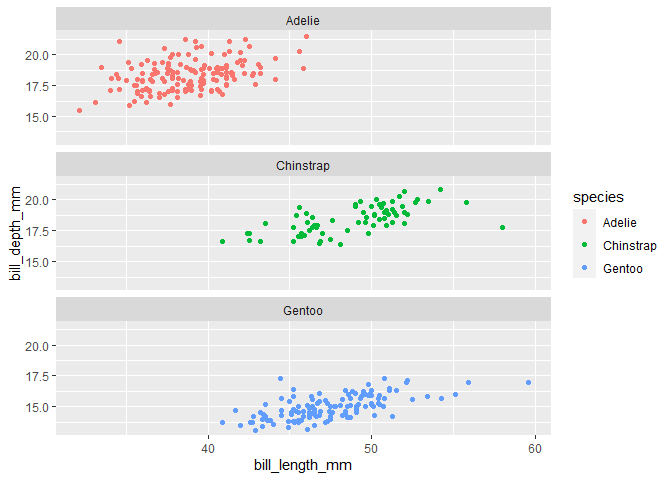

```r
p4 + facet_wrap(~ species, nrow = 3)
```

If we wish to see this relationship by both species and sex, we can just keep species mapped to the colour aesthetic and facet by sex instead.

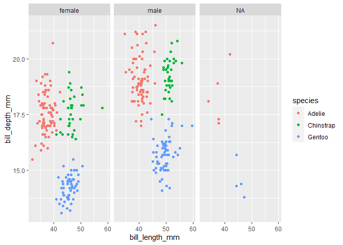

```r
p4 + facet_wrap(~ sex)
```

If we want to create a grid of facets, where the rows and columns correspond to different variables, we can use `facet_grid()` instead. The variable before the ~ will correspond to the rows, and the variable after the ~ will correspond to the columns.

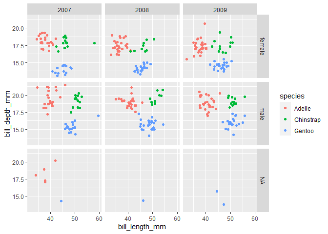

```r
p4 + facet_grid(sex ~ year)
```

## 5.7 Customizing labels

If we want to share our plot with others in a report or publication, we’ll probably want it to have a nice title and labels. We can easily add a title and change the default labels by adding a `labs()` layer to our plot.

> Note: by giving the col aesthetic a label, we are changing the label of the legend for this aesthetic.

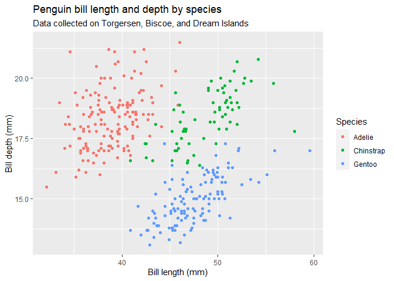

```r
p5 <- p4 + labs(title = "Penguin bill length and depth by species",
                subtitle = "Data collected on Torgersen, Biscoe, and Dream Islands",
                x = "Bill length (mm)",
                y = "Bill depth (mm)",
                col = "Species")

p5
```

## 5.8 Customising the look of your plot with themes

### 5.8.1 Pre-built themes

You can customize pretty much any feature of your ggplots, such as the presence of gridlines and tickmarks, font size, and the colour of the plot background. While you can change all these elements individually, a good starting place is to use one of the pre-built *themes*. Below, we reproduce p5 using the different pre-built themes, by adding the theme as a layer.

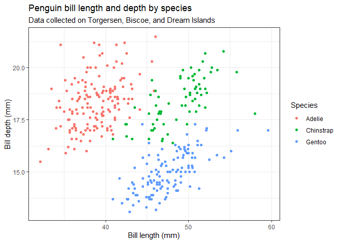

```r
p5 + theme_bw()
```

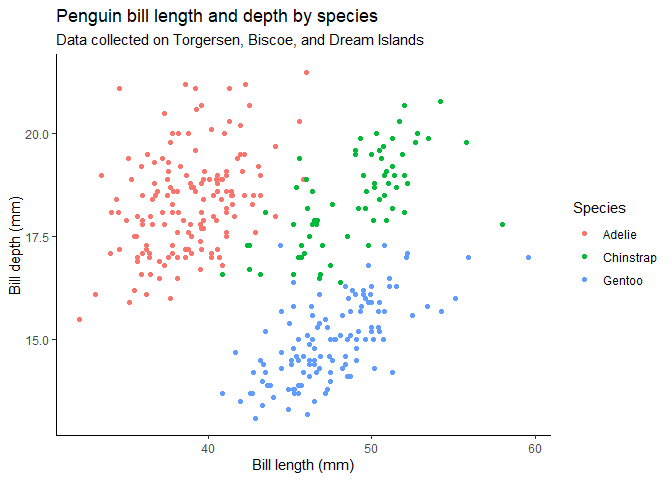

```r
p5 + theme_classic()
```

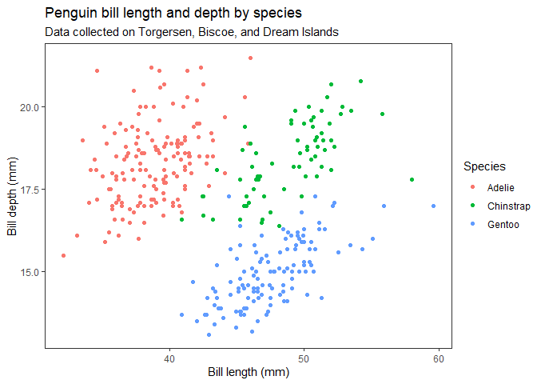

```r
p5 + theme_test()
```

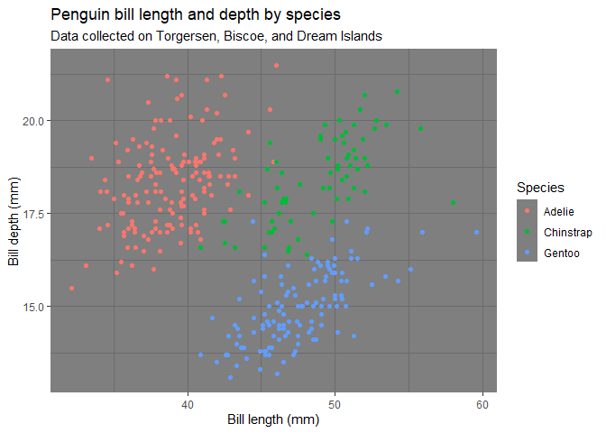

```r
p5 + theme_dark()
```

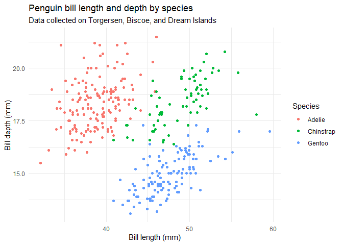

```r
p5 + theme_minimal()
```

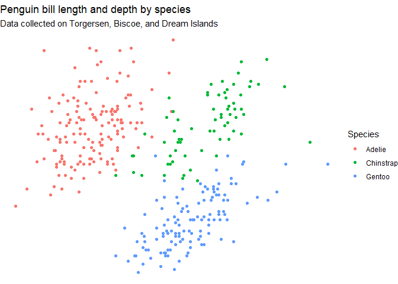

```r
p5 + theme_void()
```

### 5.8.2 Customising themes

Once you’ve found a theme that most closely resembles the design you’re looking for, you can further customize plot elements using the `theme()` function. If we call `?theme()`, we can see there is a long list of plot components that you can edit. A web search engine is your friend here, searching online for the change you wish to make will usually lead you to the correct theme element.

```r
?theme
```

Most theme elements are customised using a particular *theme function*. For example:

- line elements are customized using `element_line()`
- rectangle elements are customized using `element_rect()`
- text elements are customized using `element_text()`
- `element_blank()` is used to remove a particular element

The settings for the theme element we’re adjusting go inside the theme function. In the example below, we first remove the minor gridlines for the x and y axes, change the colour of the background, set a black border around the legend, and manually adjust the legend’s position.

> Note: the `legend.position` theme element doesn’t use a theme function, but instead takes a vector of length 2, where the first element is the distance along the horizontal, and the second element is the distance along the vertical plane.

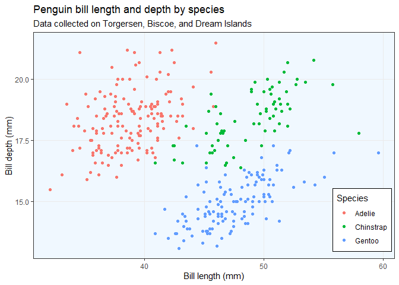

```r
p5 +
    theme_bw() +
    theme(panel.grid.minor.x = element_blank(),
          panel.grid.minor.y = element_blank(),
          panel.background = element_rect(fill = "aliceblue"),
          legend.background = element_rect(colour = "black"),
          legend.position = c(0.91, 0.17))
```

## 5.9 Saving plots

Once you have created a plot to be proud of, you can save it as an image (.eps, .ps, .tex (pictex), .pdf, .jpeg, .tiff, .png, .bmp, .svg or .wmf) using the `ggsave()` function. This will save *the last ggplot you plotted in R*. The first argument specifies the file name (including the file extension of the type you wish to save as), and arguments that control the size of the plot. It’s usual to experiment with increasing and decreasing the dimensions of the image until you find a sizing that works. For example, you’ll find as you make the image larger, the text will be smaller, relative to the overall size.

```r
ggsave("plots/Graph 1.pdf", width = 6, height = 6, units = "in")
```